# Time Series Basics

Maurício Collaça

August 5, 2018

# 1 A random normal series

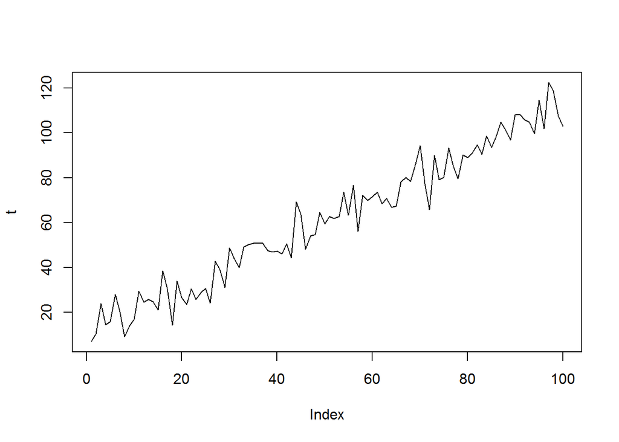

```r
set.seed(123)
t <- seq(from = 1, to = 100, by = 1) + 10 + rnorm(100, sd = 7)
plot(t, type="l")
```

Normality test

```r
shapiro.test(t)
```

```
    Shapiro-Wilk normality test

data:  t
W = 0.96631, p-value = 0.01163
```

Histogram

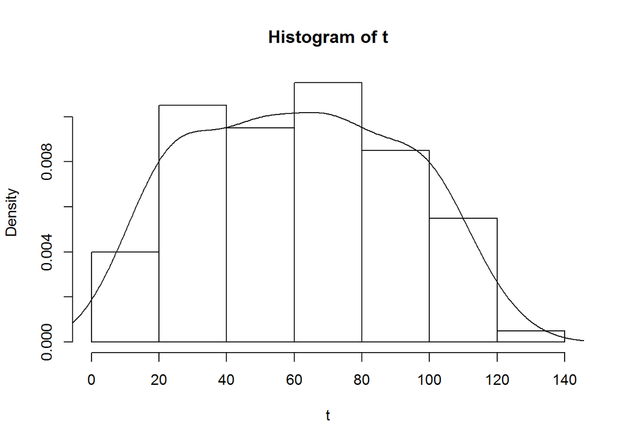

```r
hist(t, prob=TRUE)
lines(density(t))
```

Normal Q-Q plot

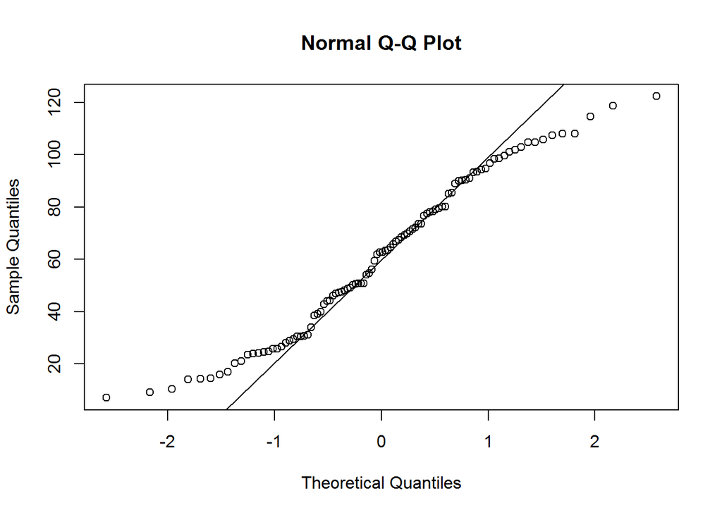

```r
qqnorm(t)
qqline(t)
```

# 2 Time Series Objects

## 2.1 ts() function arguments

```r
args(ts)
```

```
function (data = NA, start = 1, end = numeric(), frequency = 1,
    deltat = 1, ts.eps = getOption("ts.eps"), class = if (nseries >
        1) c("mts", "ts", "matrix") else "ts", names = if (!is.null(dimnames(data))) colnames(data) else paste("Series",
        seq(nseries)))
NULL
```

## 2.2 Create quarterly data from the first quarter of 2000 on

```r
(tseries <- ts(t, start = c(2000, 1), frequency = 4))
```

```
           Qtr1       Qtr2       Qtr3       Qtr4
2000   7.076670  10.388758  23.910958  14.493559
2001  15.905014  28.005455  20.226413   9.144571
2002  14.192030  16.880366  29.568573  24.518697
2003  25.805400  24.774779  21.109112  38.508392
2004  30.484953  14.233680  33.909491  26.690460
2005  23.525234  30.474176  25.817969  28.897761
2006  30.624725  24.193147  42.864509  39.073612
2007  31.033041  48.776704  43.985250  39.934500
2008  49.265880  50.146934  50.751068  50.820482
2009  50.877424  47.566618  46.858261  47.336703
2010  46.137051  50.544579  44.142226  69.182692
2011  63.455734  48.138240  54.179806  54.733413
2012  64.459756  59.416417  62.773230  61.800173
2013  62.699907  73.580216  63.419603  76.615294
2014  56.158730  72.092296  69.866980  71.511591
2015  73.657476  68.483736  70.667548  66.869972
2016  67.497461  78.124700  80.137468  78.371030
2017  85.455872  94.350593  77.562782  65.835818
2018  90.040170  79.035595  80.183940  93.179000
2019  85.006589  79.454976  90.269124  89.027760
2020  91.040349  94.696963  90.405380  98.510636
2021  93.456594  98.322474 104.677873 101.046270
2022  96.718479 108.041653 107.954527 105.838779
2023 104.671122  99.604657 114.524567 101.798183
2024 122.311331 118.728274 107.350097 102.815054
```

## 2.3 plot(), actually plot.ts()

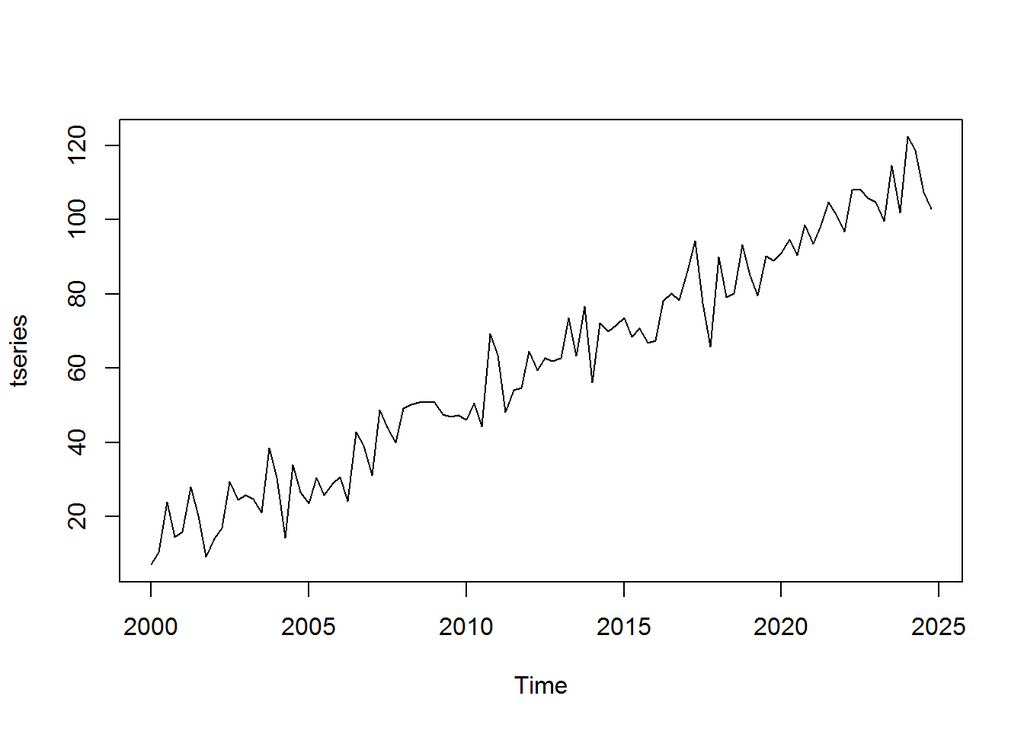

```r
plot(tseries)
```

## 2.4 Multiple series.

```r
set.seed(123)
seq <- seq(from = 1, to = 25, by = 1) + 10
ts1 <- seq + rnorm(25, sd = 5)
ts2 <- seq + rnorm(25, sd = 12)
ts3 <- seq^2 + rnorm(25, sd = 300)
tsm <- cbind(ts1, ts2, ts3)
(tsm <- ts(tsm, start=c(2000, 1), frequency = 4))
```

```
              ts1        ts2       ts3
2000 Q1  8.197622 -9.2403197  196.9956
2000 Q2 10.849113 22.0534445  135.4360
2000 Q3 20.793542 14.8404774  156.1389
2000 Q4 14.352542  0.3423568  606.5807
2001 Q1 15.646439 30.0457791  157.2687
2001 Q2 24.575325 21.1175707  710.9412
2001 Q3 19.304581 13.4591422 -175.6258
2001 Q4 11.674694 28.7415079  499.3841
2002 Q1 15.565736 29.5376019  398.1563
2002 Q2 17.771690 29.8589730  464.7825
2002 Q3 27.120409 29.2636830  554.8918
2002 Q4 23.799069 28.6470118  333.3030
2003 Q1 25.003857 22.2570595  429.0378
2003 Q2 24.553414 20.3284480  270.4274
2003 Q3 22.220794 20.4343480  303.4626
2003 Q4 34.934566 17.6635163  767.0586
2004 Q1 29.489252 24.5049927  863.4629
2004 Q2 18.166914 12.8152438  799.9013
2004 Q3 32.506780 55.0274716 1117.6802
2004 Q4 27.636043 44.4955440 1515.0254
2005 Q1 25.660881 17.5226970  813.6907
2005 Q2 30.910125 27.1653820  331.2493
2005 Q3 27.869978 27.4001358 1390.7216
2005 Q4 30.355544 43.3595814  943.2398
2006 Q1 31.874804 33.9995712 1018.5974
```

## 2.5 plot multiple series by default

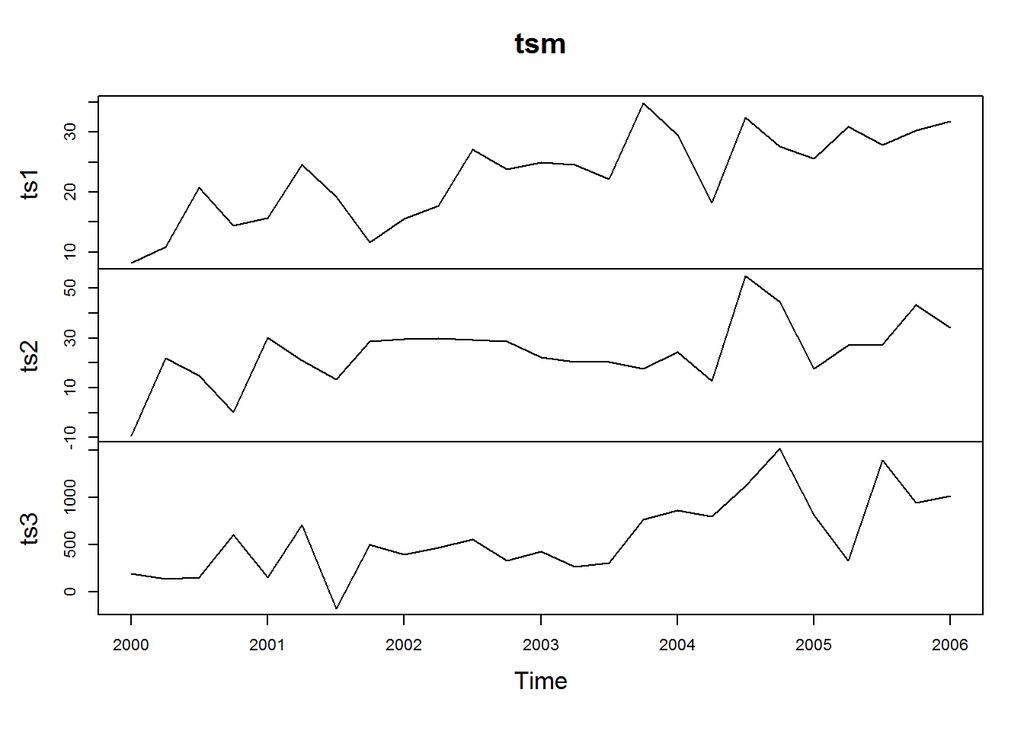

```r
plot(tsm)
```

## 2.6 plot.ts() arguments

```r
args(plot.ts)
```

```
function (x, y = NULL, plot.type = c("multiple", "single"), xy.labels,
    xy.lines, panel = lines, nc, yax.flip = FALSE, mar.multi = c(0,
        5.1, 0, if (yax.flip) 5.1 else 2.1), oma.multi = c(6,
        0, 5, 0), axes = TRUE, ...)
NULL
```

## 2.7 plot multiple series in single panel

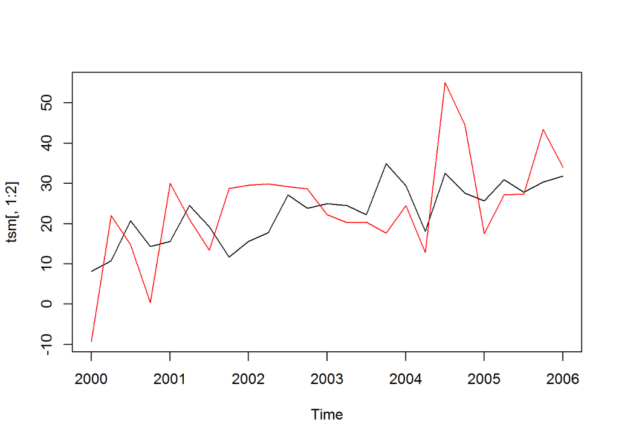

```r
plot(tsm[,1:2], plot.type=c("single"), col=1:2)
```

# 3 Convenience Functions for Time Series

## 3.1 start() and end() - terminal times

```r
start(tseries)
```

```
[1] 2000    1
```

```r
end(tseries)
```

```
[1] 2024    4
```

## 3.2 window() - subset by time

Only the data from the first quarter of 2000 to the last quarter of 2012

```r
(tseries_sub <- window(tseries, start=c(2000, 1), end=c(2012,4)))
```

```
          Qtr1      Qtr2      Qtr3      Qtr4
2000  7.076670 10.388758 23.910958 14.493559
2001 15.905014 28.005455 20.226413  9.144571
2002 14.192030 16.880366 29.568573 24.518697
2003 25.805400 24.774779 21.109112 38.508392
2004 30.484953 14.233680 33.909491 26.690460
2005 23.525234 30.474176 25.817969 28.897761
2006 30.624725 24.193147 42.864509 39.073612
2007 31.033041 48.776704 43.985250 39.934500
2008 49.265880 50.146934 50.751068 50.820482
2009 50.877424 47.566618 46.858261 47.336703
2010 46.137051 50.544579 44.142226 69.182692
2011 63.455734 48.138240 54.179806 54.733413
2012 64.459756 59.416417 62.773230 61.800173
```

## 3.3 frequency() - Number of samples per unit time

```r
frequency(tseries)
```

```
[1] 4
```

## 3.4 cycle() - Positions in the cycle of each observation

```r
cycle(tseries)
```

```
     Qtr1 Qtr2 Qtr3 Qtr4
2000    1    2    3    4
2001    1    2    3    4
2002    1    2    3    4
2003    1    2    3    4
2004    1    2    3    4
2005    1    2    3    4
2006    1    2    3    4
2007    1    2    3    4
2008    1    2    3    4
2009    1    2    3    4
2010    1    2    3    4
2011    1    2    3    4
2012    1    2    3    4
2013    1    2    3    4
2014    1    2    3    4
2015    1    2    3    4
2016    1    2    3    4
2017    1    2    3    4
2018    1    2    3    4
2019    1    2    3    4
2020    1    2    3    4
2021    1    2    3    4
2022    1    2    3    4
2023    1    2    3    4
2024    1    2    3    4
```

## 3.5 deltat() - Interval time between observations

```r
deltat(tseries)
```

```
[1] 0.25
```

## 3.6 time() - Sampling times

```r
time(tseries)
```

```
        Qtr1    Qtr2    Qtr3    Qtr4
2000 2000.00 2000.25 2000.50 2000.75
2001 2001.00 2001.25 2001.50 2001.75
2002 2002.00 2002.25 2002.50 2002.75
2003 2003.00 2003.25 2003.50 2003.75
2004 2004.00 2004.25 2004.50 2004.75
2005 2005.00 2005.25 2005.50 2005.75
2006 2006.00 2006.25 2006.50 2006.75
2007 2007.00 2007.25 2007.50 2007.75
2008 2008.00 2008.25 2008.50 2008.75
2009 2009.00 2009.25 2009.50 2009.75
2010 2010.00 2010.25 2010.50 2010.75
2011 2011.00 2011.25 2011.50 2011.75
2012 2012.00 2012.25 2012.50 2012.75
2013 2013.00 2013.25 2013.50 2013.75
2014 2014.00 2014.25 2014.50 2014.75
2015 2015.00 2015.25 2015.50 2015.75
2016 2016.00 2016.25 2016.50 2016.75
2017 2017.00 2017.25 2017.50 2017.75
2018 2018.00 2018.25 2018.50 2018.75
2019 2019.00 2019.25 2019.50 2019.75
2020 2020.00 2020.25 2020.50 2020.75
2021 2021.00 2021.25 2021.50 2021.75
2022 2022.00 2022.25 2022.50 2022.75
2023 2023.00 2023.25 2023.50 2023.75
2024 2024.00 2024.25 2024.50 2024.75
```

# 4 Time Series transformations

There are a number of different functions that can be used to transform time series data such as the difference, log, moving average, percent change, lag, or cumulative sum.

For example, the moving average function can be used to more easily visualize a high-variance time series and is also a critical part the ARIMA family of models. Functions such as the difference, percent change, and log difference are helpful for making non-stationary data stationary.

## 4.1 Lag

Compute a lagged version of a time series, shifting the time base back (positive lag) or forth (negative lag) by a given number of observations

Lag 1 unit of observation

```r
tseries_lag1 <- lag(tseries, 1)
head(cbind(tseries, tseries_lag1))
```

```
      tseries tseries_lag1
[1,]       NA      7.07667
[2,]  7.07667     10.38876
[3,] 10.38876     23.91096
[4,] 23.91096     14.49356
[5,] 14.49356     15.90501
[6,] 15.90501     28.00545
```

Lag 3 units of observation

```r
tseries_lag3 <- lag(tseries, 3)
head(cbind(tseries, tseries_lag3))
```

```
      tseries tseries_lag3
[1,]       NA      7.07667
[2,]       NA     10.38876
[3,]       NA     23.91096
[4,]  7.07667     14.49356
[5,] 10.38876     15.90501
[6,] 23.91096     28.00545
```

Lead 1 unit of observation

```r
tseries_lead1 <- lag(tseries, -1)
head(cbind(tseries, tseries_lead1))
```

```
      tseries tseries_lead1
[1,]  7.07667            NA
[2,] 10.38876       7.07667
[3,] 23.91096      10.38876
[4,] 14.49356      23.91096
[5,] 15.90501      14.49356
[6,] 28.00545      15.90501
```

## 4.2 Difference

diff() removes a linear trend, producing a so called change series or difference series

### 4.2.1 Removing a linear trend

Difference between each value and its previous value (lag 1)

```r
tseries_diff1 <- diff(tseries, lag = 1)
tsd1 <- cbind(tseries, tseries_diff1)
head(tsd1)
```

```
      tseries tseries_diff1
[1,]  7.07667            NA
[2,] 10.38876      3.312087
[3,] 23.91096     13.522201
[4,] 14.49356     -9.417399
[5,] 15.90501      1.411455
[6,] 28.00545     12.100441
```

Taking a difference is an effective way to remove a trend and make a time series stationary

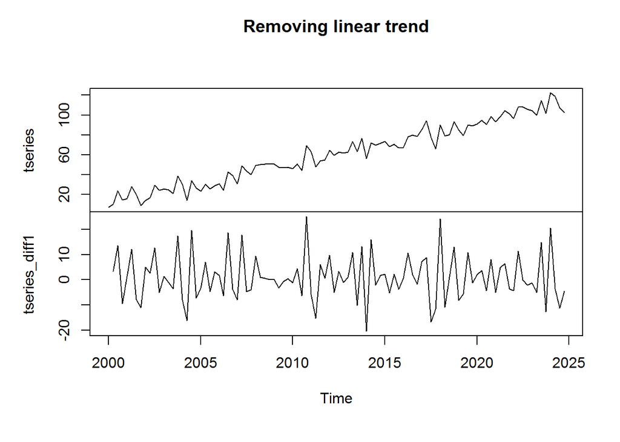

```r
plot(tsd1, main="Removing linear trend")
```

### 4.2.2 Removing a seasonal trend

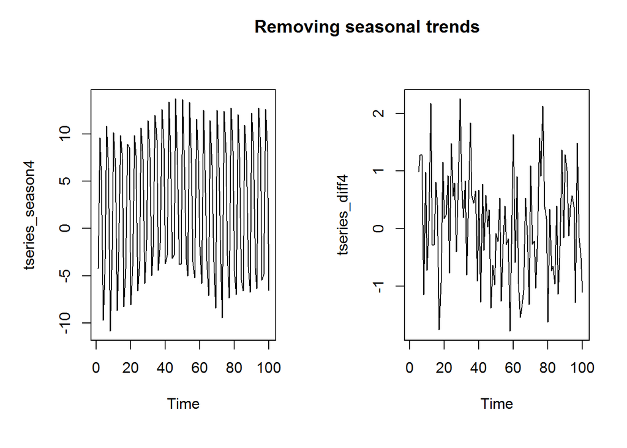

```r
tseries_diff4 <- diff(tseries_season4, lag=4)
plot.ts(cbind(tseries_season4, tseries_diff4), nc=2, main="Removing seasonal trends")
```

## 4.3 Heteroskedasticity: non-constant (e.g. increasing) variance

The prevalence of increasing, or more generally non-constant, variance is called heteroskedasticity, i.e., sub-populations having difference variance from others, and can cause problems in linear regression. Often, it will need to be corrected before modeling.

Simulating a time series with increasing variance:

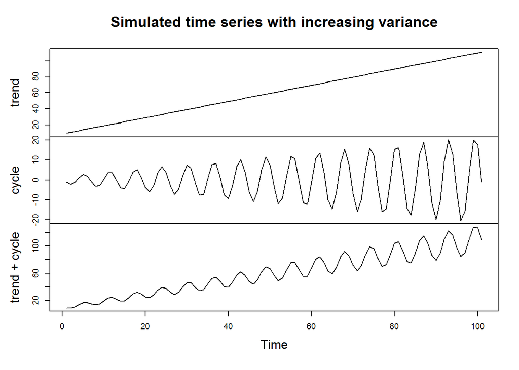

```r
trend <- ts(seq(from = 10, to = 110))
cycle <- ts(sin(trend)) * 0.2 * trend
tseries_h <- trend + cycle
plot(cbind(trend, cycle, "trend + cycle"=tseries_h), main="Simulated time series with increasing variance")
```

Some time series transformation functions are useful for series in which the variance gets larger over time. These range from the *basic logarithm function* to the *Box-Cox group of transformations* (of which the natural logarithm is a special case).

## 4.4 Log transformation of a series

### 4.4.1 Correcting heteroskedasticity

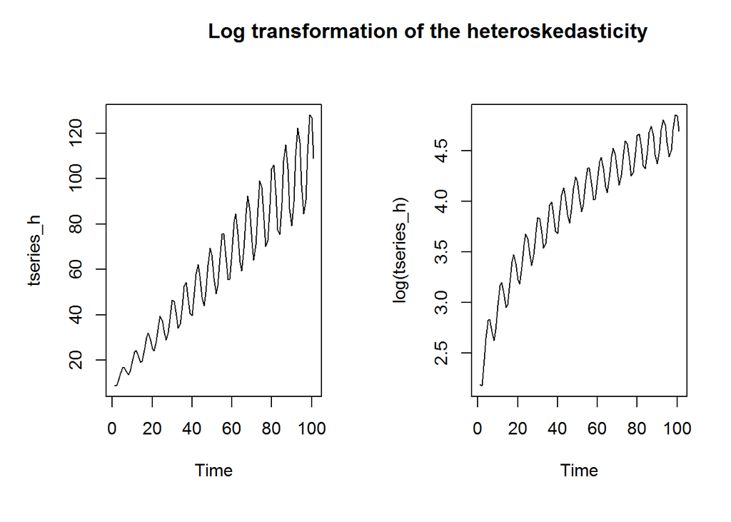

```r
plot(cbind(tseries_h, log(tseries_h)), nc=2, main="Log transformation of the heteroskedasticity")
```

### 4.4.2 Linearizing a rapid growth trend

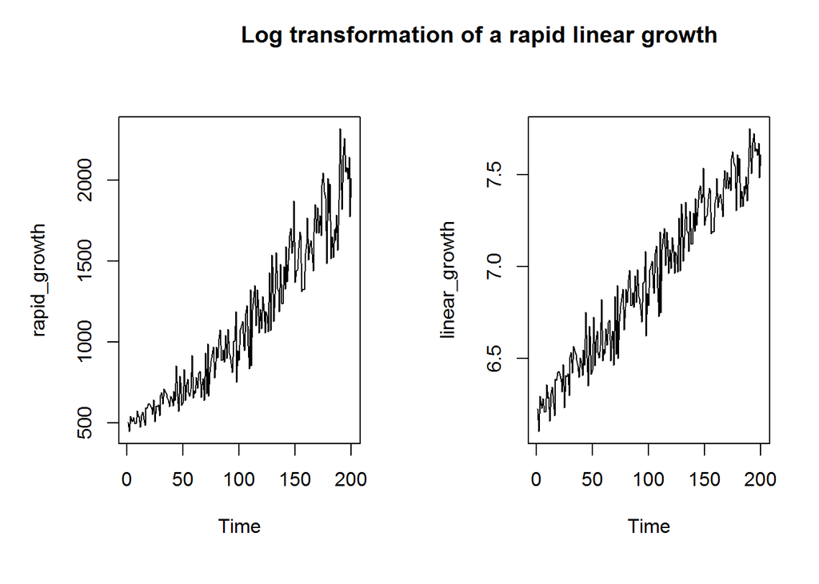

```r
plot.ts(cbind(rapid_growth, linear_growth=log(rapid_growth)), plot.type = "multiple", nc=2,
        main="Log transformation of a rapid linear growth")
```

## 4.5 BoxCox() transformation: corrects heteroskedasticity

There are other more advanced ways of eliminating non-constant variance (heteroskedasticity), one of which is the **Box-Cox transformation**, which allows us a bit more control over the transformation. The Box-Cox takes the form (Hyndman and Athanasopoulos, 2013):

$$w_t = \begin{cases} \log{ y_t }, \text{ if } \lambda = 0; \\ \frac{ ({y_t}^{\lambda} – 1) }{ \lambda },\text{ otherwise } \\ \end{cases}$$

```r
library(forecast)
```

It has two functions that are of use here. The primary function is BoxCox(), which will return a transformed time series given a time series and a value for the parameter lambda:

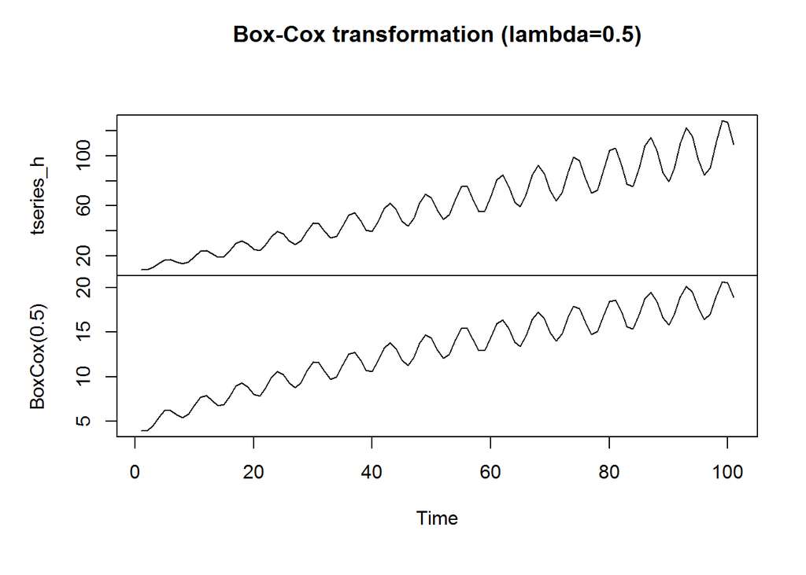

```r
plot.ts(cbind(tseries_h, "BoxCox(0.5)"=BoxCox(tseries_h, lambda = 0.5)), main="Box-Cox transformation (lambda=0.5)")
```

Notice that this value **0.5** of lambda here does not entirely take care of the heteroskedasticity problem. We can experiment with different values of lambda, or we can use the **BoxCox.lambda()** function, which will provide us an optimal value for parameter lambda:

```r
(lambda <- BoxCox.lambda(tseries_h))
```

```
[1] 0.05527724
```

The BoxCox.lambda() function has chosen the value 0.055. If we then use this value in our BoxCox() function, it returns a time series that appears to have constant variance.

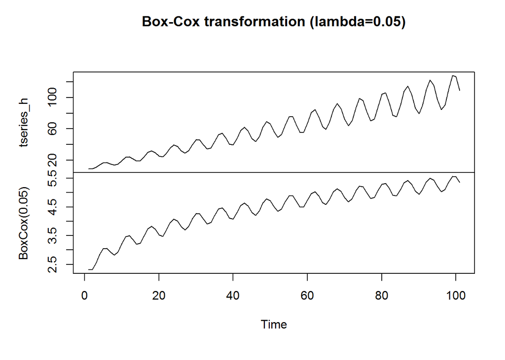

```r
plot.ts(cbind(tseries_h, "BoxCox(0.05)"=BoxCox(tseries_h, lambda = lambda)), main="Box-Cox transformation (lambda=0.05)")
```

## 4.6 Percent change: remove trend & make stationary

Another common calculation that we may want to perform on time series is the **percent change** from one period to another. A function to easily calculate percent change with an argument to specify the number of periods over which we want to calculate the change, defaults 1.

```r
pch <- function(data, lag = 1) {
    if (!is.ts(data)) stop("data must be of type ts")
    if (!is.numeric(lag)) stop("lag must be of type numeric")
    data / lag(data, -lag) - 1
}
```

Quarterly percent change

```r
pch_quarter <- pch(tseries)
head(cbind(tseries, pch_quarter))
```

```
         tseries pch_quarter
2000 Q1  7.07667          NA
2000 Q2 10.38876  0.46802901
2000 Q3 23.91096  1.30161865
2000 Q4 14.49356 -0.39385287
2001 Q1 15.90501  0.09738501
2001 Q2 28.00545  0.76079409
```

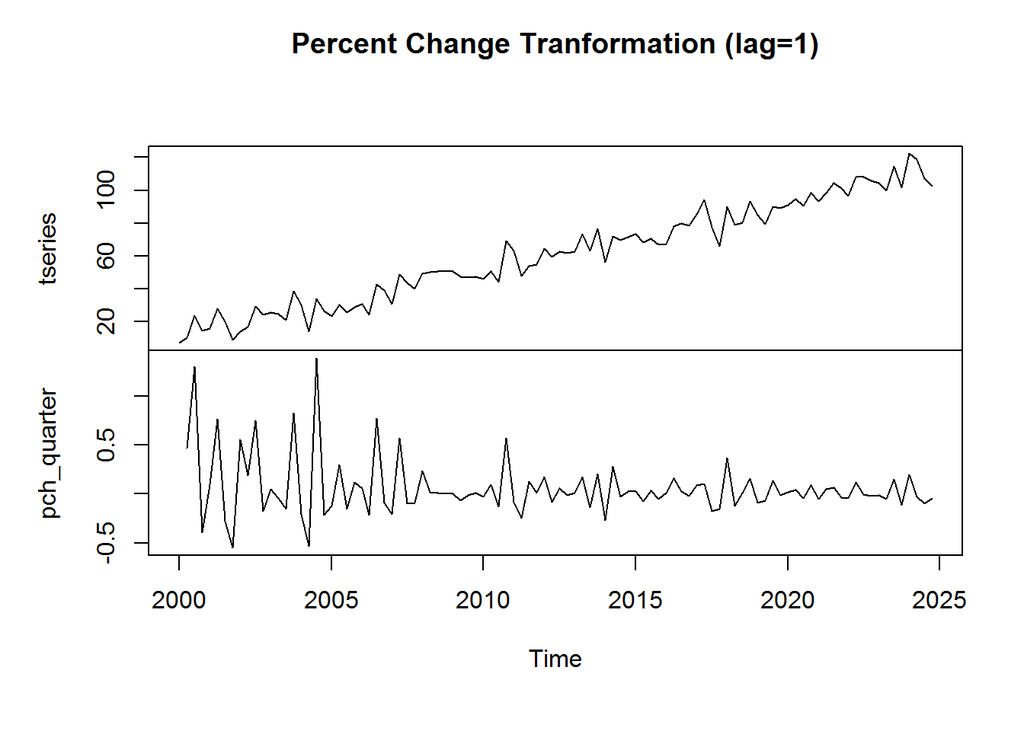

```r
plot(cbind(tseries, pch_quarter), main="Percent Change Tranformation (lag=1)")
```

Year over year percent change

```r
pch_year <- pch(tseries, lag=4)
head(cbind(tseries, pch_year))
```

```
         tseries pch_year
2000 Q1  7.07667       NA
2000 Q2 10.38876       NA
2000 Q3 23.91096       NA
2000 Q4 14.49356       NA
2001 Q1 15.90501 1.247528
2001 Q2 28.00545 1.695746
```

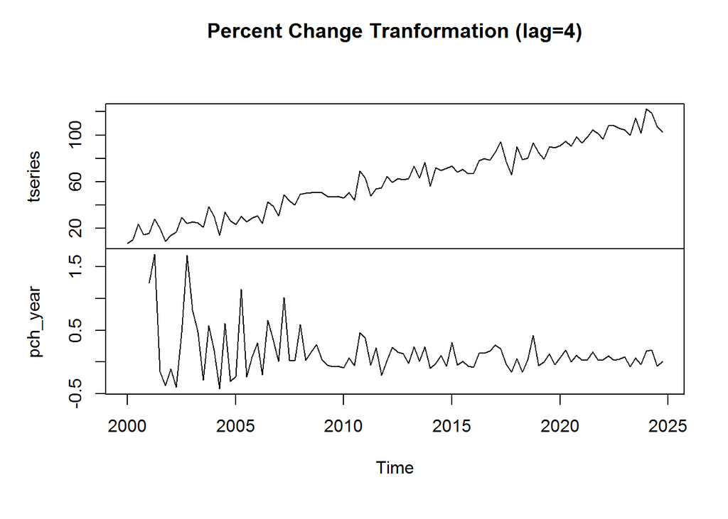

```r
plot(cbind(tseries, pch_year), main="Percent Change Tranformation (lag=4)")
```

## 4.7 Log difference: remove trend & make stationary

Two of the functions that we have discussed so far, the difference and the log, are often combined in time series analysis. The **log difference** function is useful for making non-stationary data stationary and has some other useful properties.

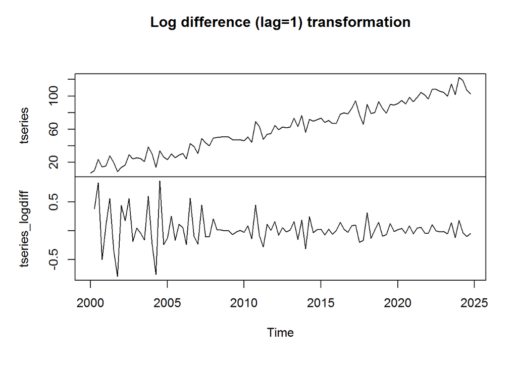

```r
tseries_logdiff <- diff(log(tseries))
plot.ts(cbind(tseries, tseries_logdiff), main="Log difference (lag=1) transformation")
```

Notice that after taking the log return, tseries appears to be stationary. We see some higher than normal volatility in the beginning of the series. This is due largely to the fact that the series levels start off so small. This leads into a nice property of the **log diference return function: a close approximation to the percent change**:

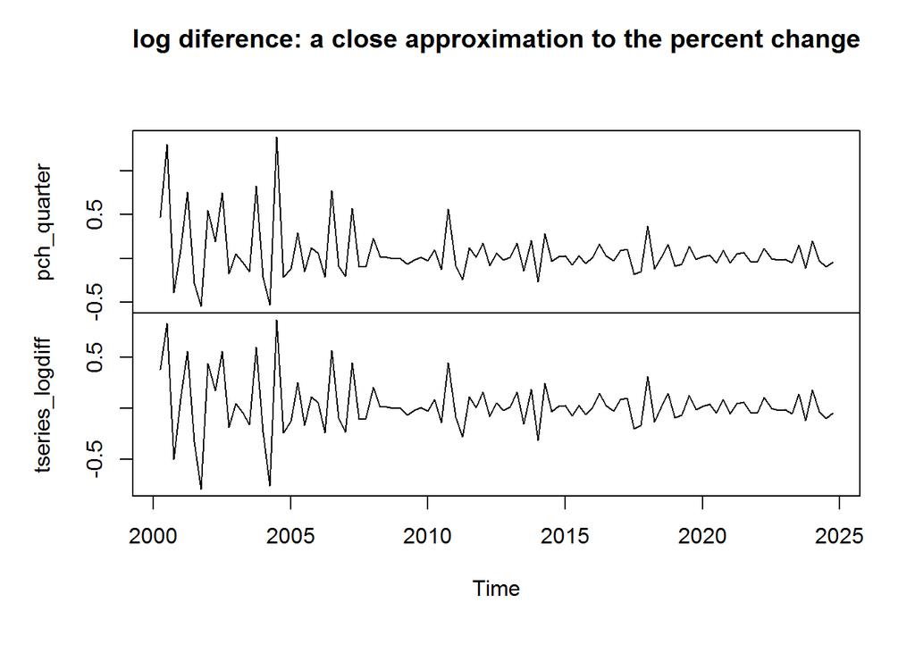

```r
plot.ts(cbind(pch_quarter, tseries_logdiff),
        main="log diference: a close approximation to the percent change")
```

This similarity is only approximate. The relationship does break down somewhat when the percent change from one period to the next is particularly large. You can read a good discussion of this topic [here](https://stats.stackexchange.com/questions/244199/why-is-it-that-natural-log-changes-are-percentage-changes-what-is-about-logs-th).

## 4.8 Moving average: Smoothing/trending

A **moving average** is another essential function for working with time series. For series with particularly high volatility, a moving average can help us to more clearly visualize its trend. We can use base R’s filter() function, which allows us to perform general linear filtering. We can set up the parameters of this function to be a moving average (Shumway and Stoffer, 2011). Here we apply the filter() function to tseries to create a 5 period moving average. The filter argument lets up specify the filter, which in this case is just a weighted average of 5 observations. The sides argument allows us to specify whether we want to apply the filter over past values (sides = 1), or to both past and future values (sides = 2).

```r
tseries_lf5 <- filter(tseries, filter = rep(1/5, 5), sides = 1)
head(cbind(tseries, tseries_lf5))
```

```
         tseries tseries_lf5
2000 Q1  7.07667          NA
2000 Q2 10.38876          NA
2000 Q3 23.91096          NA
2000 Q4 14.49356          NA
2001 Q1 15.90501    14.35499
2001 Q2 28.00545    18.54075
```

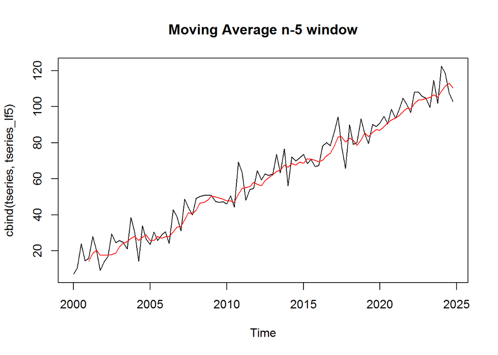

```r
plot.ts(cbind(tseries, tseries_lf5), plot.type='single', col=1:2,
        main="Moving Average n-5 window")
```

The fact that we have to define the linear filter each time we use this function makes it a little cumbersome to use. If we don’t mind introducing a dependency to our code, we could use the `SMA()` function from the `TTR` package or the `ma()` function from the `forecast` package. The SMA() function takes a ts object and a value for n – the window over which we want to calculate the moving average.

```r
library(TTR)
tseries_ma5 <- SMA(tseries, n = 5)
```

The `ma()` function from the `forecast` package also performs moving average calculations. We supply the time series and a value for the order argument.

```r
tseries_ma5fore <- ma(tseries, order = 5)
```

Let’s compare the results. The SMA() function returns a trailing moving average where each value is the mean of the n most recent trailing values. This is equivalent to the results we get from using the `filter()` function. The `ma()` function from the forecast package returns a centered moving average. In this case tseries_ma5for is equal to the average of the current observation, the previous two observation, and the next two observations. Which one you use would depend on your application.

```r
head(cbind(tseries, tseries_lf5, tseries_ma5, tseries_ma5fore),10)
```

```
          tseries tseries_lf5 tseries_ma5 tseries_ma5fore
2000 Q1  7.076670          NA          NA              NA
2000 Q2 10.388758          NA          NA              NA
2000 Q3 23.910958          NA          NA        14.35499
2000 Q4 14.493559          NA          NA        18.54075
2001 Q1 15.905014    14.35499    14.35499        20.50828
2001 Q2 28.005455    18.54075    18.54075        17.55500
2001 Q3 20.226413    20.50828    20.50828        17.49470
2001 Q4  9.144571    17.55500    17.55500        17.68977
2002 Q1 14.192030    17.49470    17.49470        18.00239
2002 Q2 16.880366    17.68977    17.68977        18.86085
```

# 5 Real data with Quandl API

Quandl has a great warehouse of financial, economic and alternative data, some of which is free.

Below is an example of using the Quandl R package to get housing price index data. You can find this data on the web [here](https://www.quandl.com/data/YALE/NHPI-Historical-Housing-Market-Data-Nominal-Home-Price-Index).

```r
library(Quandl)
```

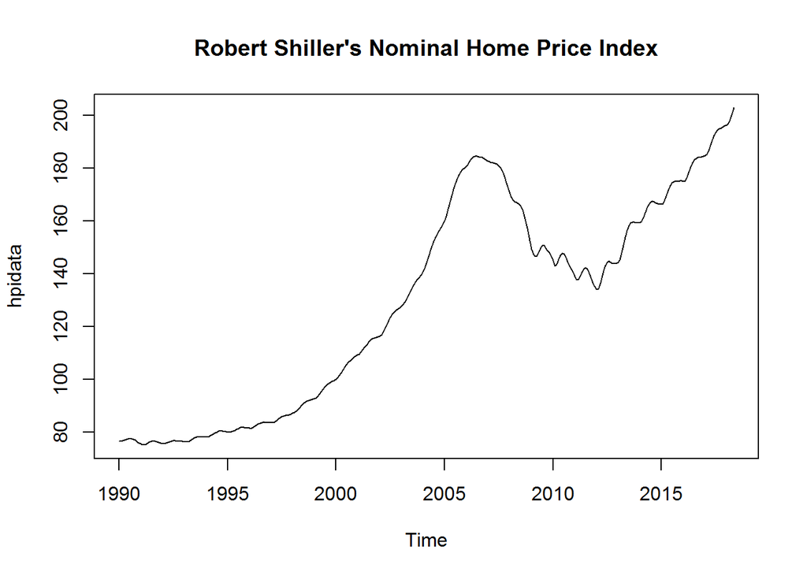

```r
Quandl.api_key(readLines("Quandl.api_key.txt",1))
hpidata <- Quandl("YALE/NHPI", type="ts", start_date="1990-01-01")
plot(hpidata, main = "Robert Shiller's Nominal Home Price Index")
```

Data on US GDP and US personal income, and the University of Michigan Consumer Survey on selling conditions for houses. The data are located on the web [here](https://www.quandl.com/data/FRED/GDP-Gross-Domestic-Product), [here](https://www.quandl.com/data/FRED/PINCOME-Personal-Income), and [here](https://www.quandl.com/data/UMICH/SOC43-University-of-Michigan-Consumer-Survey-Selling-Conditions-for-Houses).

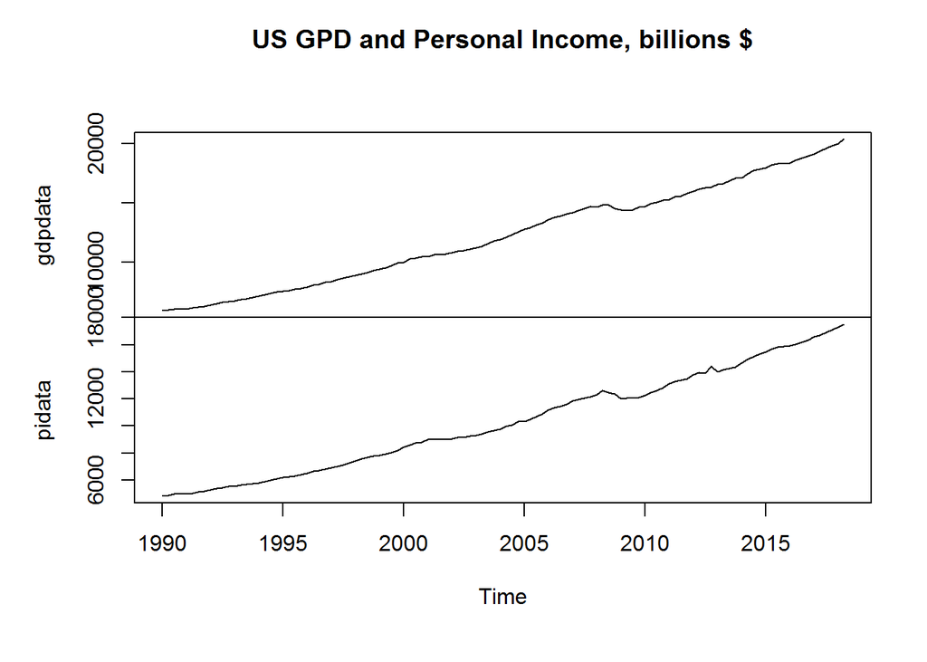

```r
gdpdata <- Quandl("FRED/GDP", type="ts", start_date="1990-01-01")
pidata <- Quandl("FRED/PINCOME", type="ts", start_date="1990-01-01")
umdata <- Quandl("UMICH/SOC43", type="ts")[, 1]
plot.ts(cbind(gdpdata, pidata),  main="US GPD and Personal Income, billions $")
```

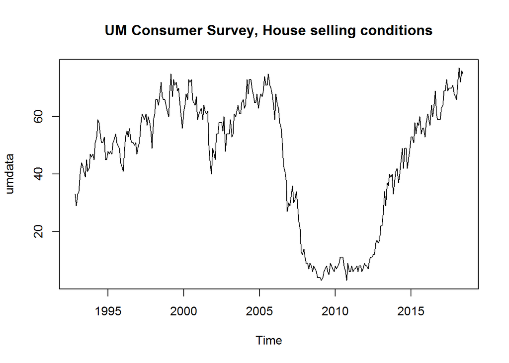

```r
plot.ts(umdata, main = "UM Consumer Survey, House selling conditions")
```

The Quandl API also has some basic options for data preprocessing. The US GDP data is in quarterly frequency…

```r
frequency(gdpdata)
```

```
[1] 4
```

… but assume we want annual data. We can use the collapse argument to collapse the data to a lower frequency. Here we covert the data to annual as we import it.

```r
gdpdata_ann <- Quandl("FRED/GDP", type="ts", start_date="1990-01-01", collapse="annual")
frequency(gdpdata_ann)
```

```
[1] 1
```

We can also transform our data on the fly as its imported. The Quandl function has a argument transform that allows us to specify the type of data transformation we want to perform. There are five options – “diff“,”rdiff“,”normalize“,”cumul“,”rdiff_from“. Specifying the transform argument as”diff” returns the simple difference, “rdiff” yields the percentage change, “normalize” gives an index where each value is that value divided by the first period value and multiplied by 100, “cumul” gives the cumulative sum, and “rdiff_from” gives each value as the percent difference between itself and the last value in the series. For more details on these transformations, check the API documentation [here](https://docs.quandl.com/).

For example, here we get the data in percent change form:

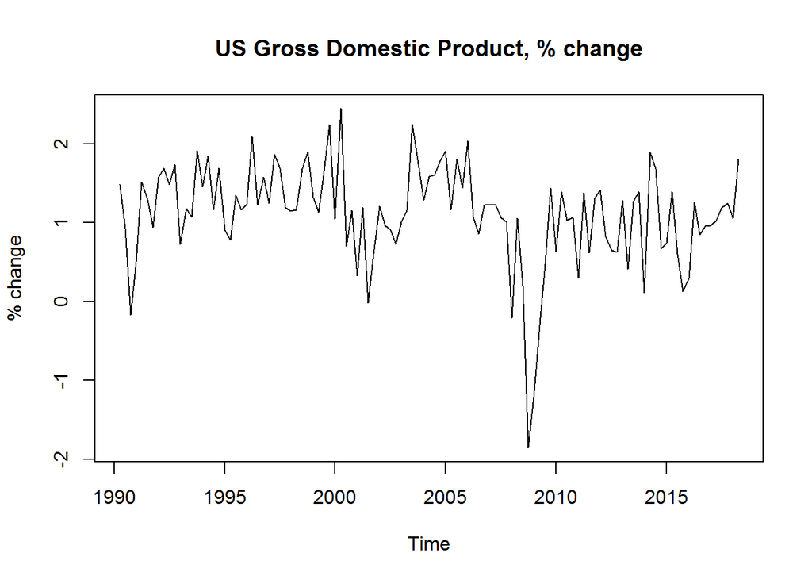

```r
gdpdata_pc <- Quandl("FRED/GDP", type="ts", start_date="1990-01-01", transform="rdiff")
plot(gdpdata_pc * 100, ylab= "% change", main="US Gross Domestic Product, % change")
```

You can find additional documentation on using the Quandl R package [here](https://docs.quandl.com/docs/r-time-series). The API allows a maximum of 50 calls per day from anonymous users. You can sign up for an account and get your own API key, which will allow you to make as many calls to the API as you like (within reason of course).

# 6 Time indexing

## 6.1 What does the time index tell us?

Some data are naturally evenly spaced by time. Discrete time indexing is appropriate for discrete_data.

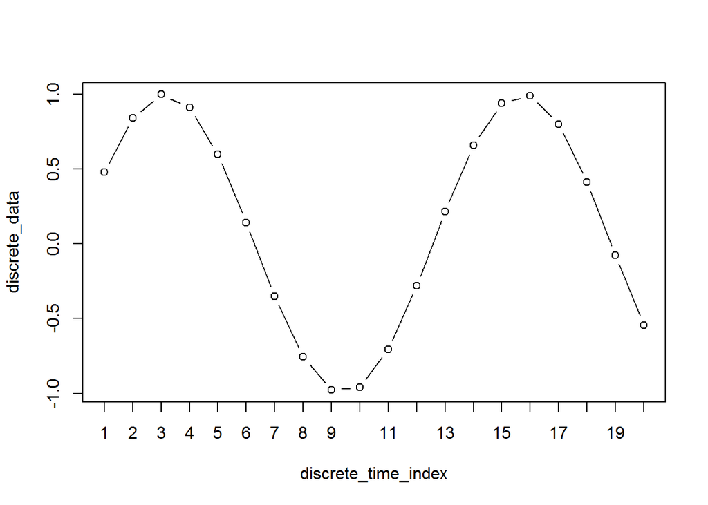

```r
discrete_data <- c(0.479425538604203, 0.841470984807897, 0.997494986604054, 0.909297426825682, 0.598472144103957, 0.141120008059867, -0.35078322768962, -0.756802495307928, -0.977530117665097, -0.958924274663138, -0.705540325570392, -0.279415498198926, 0.215119988087816, 0.656986598718789, 0.937999976774739, 0.989358246623382, 0.79848711262349, 0.412118485241757, -0.0751511204618093, -0.54402111088937)
discrete_time_index <- 1:20
plot(discrete_time_index, discrete_data, type="b", xaxt="n")
axis(1, discrete_time_index)
```

The next time series continuous_series also has 20 observations, it is following the same periodic pattern as discrete_data, but its observations are not evenly spaced. Continuous time indexing is natural for continuous_series, however, the observations are approximately evenly spaced, with about 1 observation observed per time unit.

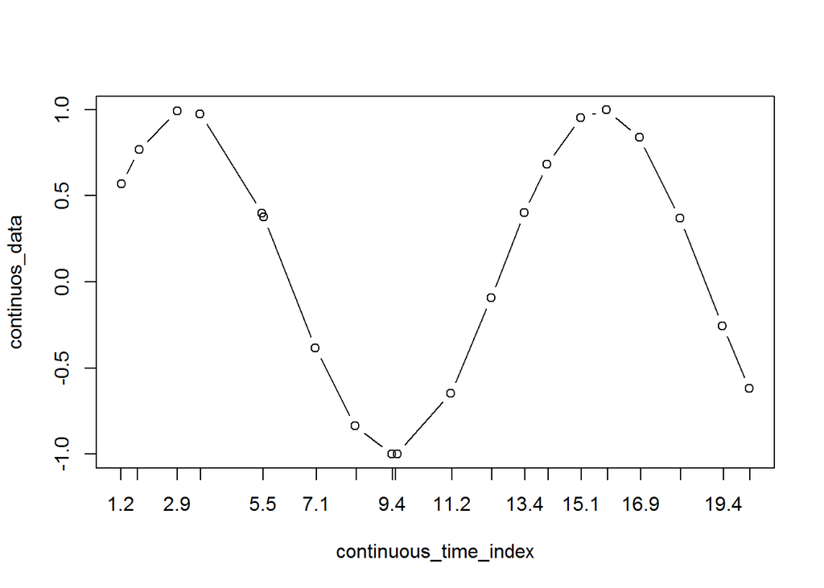

```r
continuos_data <- c(0.568894675391674, 0.766304082748762, 0.992075122074743, 0.974817414246897, 0.399123202687807, 0.37660246288782, -0.385320332818421, -0.836358518142533, -0.999669829045622, -0.998310189536195, -0.646222799842192, -0.0938615130061447, 0.400529093874378, 0.681605778899236,0.953181592214187, 0.996938027205692, 0.839341938468838, 0.370037544609373, -0.255096756784655, -0.617439825310109)
continuous_time_index <- c(1.21032244665548, 1.74613730167039, 2.88963444461115, 3.59138367255218, 5.46206454467028, 5.51093333004974, 7.0742951775901, 8.26439798949286, 9.37338230921887, 9.5410633541178, 11.1611216005404, 12.378370850347, 13.3905590295326, 14.0662804655731, 15.0935473444406, 15.8645145166665, 16.8574128514156, 18.0914570542518, 19.3654514602385, 20.1805236600339)
plot(continuous_time_index, continuos_data, type="b", xaxt="n")
axis(1, round(continuous_time_index,1))
```

Let’s investigate using a discrete time indexing for continuous_data.

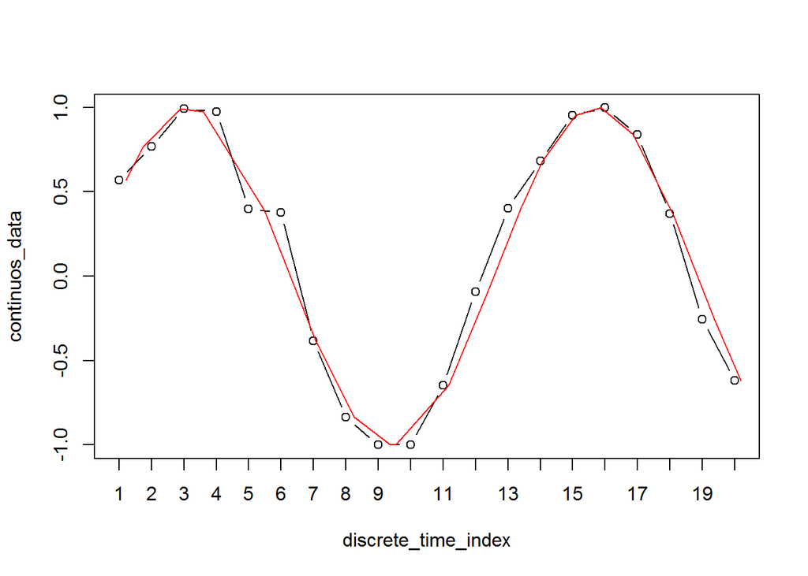

```r
plot(discrete_time_index, continuos_data, type="b", xaxt="n")
lines(loess(continuos_data ~ continuous_time_index), col=2)
axis(1, discrete_time_index)
```

Note the various differences between the resulting figures, but the approximation appears reasonable because the overall trend remained preserved.

## 6.2 Sampling Frequency

- Some time series data is exactly evenly spaced
- Some time series data is only approximately evenly spaced
- Some time series data is evenly spaced, but with missing values

Simplifying assumptions for time series:

- Consecutive observations are equally spaced
- Apply a discrete-time observation index
- This may only hold approximately

Ex. Daily log returns on stock may only be a vailable for weekdays.  
Ex. Monthly CPI values are equally spaced by month, not by day.

# 7 White Noise (WN)

White Noise (WN) is the simplest example of a stationary process.

A weak white noise process has:

- A fixed, constant mean
- A fixed, constant variance
- No correlation over time
- i.e. Idependent and Identically Distributed (IID) variables

The white noise (WN) model is a basic time series model. It is also a basis for the more elaborate models we will consider. We will focus on the simplest form of WN, independent and identically distributed data.

The arima.sim() function can be used to simulate data from a variety of time series models. ARIMA is an abbreviation for the autoregressive integrated moving average class of models we will consider throughout this course.

An ARIMA(p, d, q) model has three parts, the autoregressive order p, the order of integration (or differencing) d, and the moving average order q. ARIMA(0, 0, 0) model, i.e., with all of these components zero, is simply the WN model.

## 7.1 Simulate a WN model with $\mu$=0 and $\sigma$=1

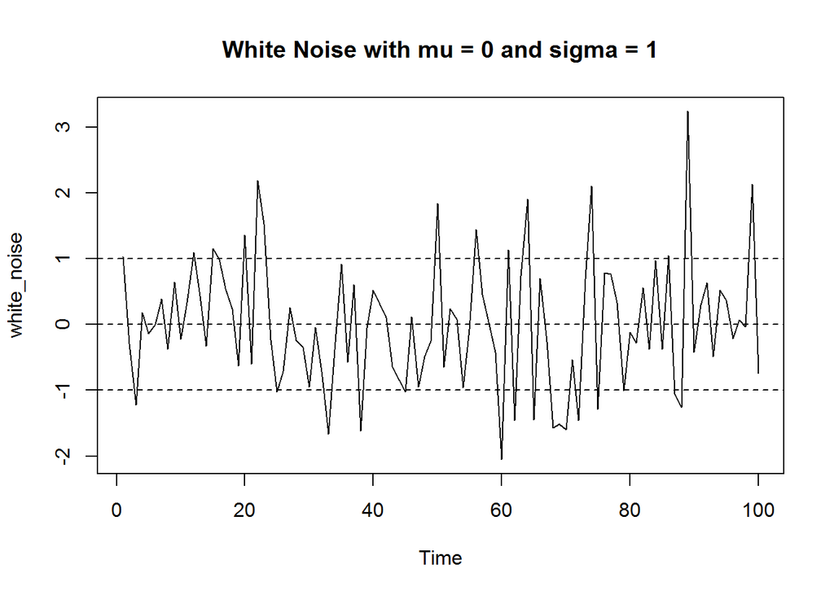

```r
white_noise <- arima.sim(model = list(order=c(0,0,0)), n = 100)
plot(white_noise, main="White Noise with mu = 0 and sigma = 1")
abline(h=c(-1,0,1), lty=2)
```

## 7.2 Simulate a WN model with $\mu$=100 and $\sigma$=10

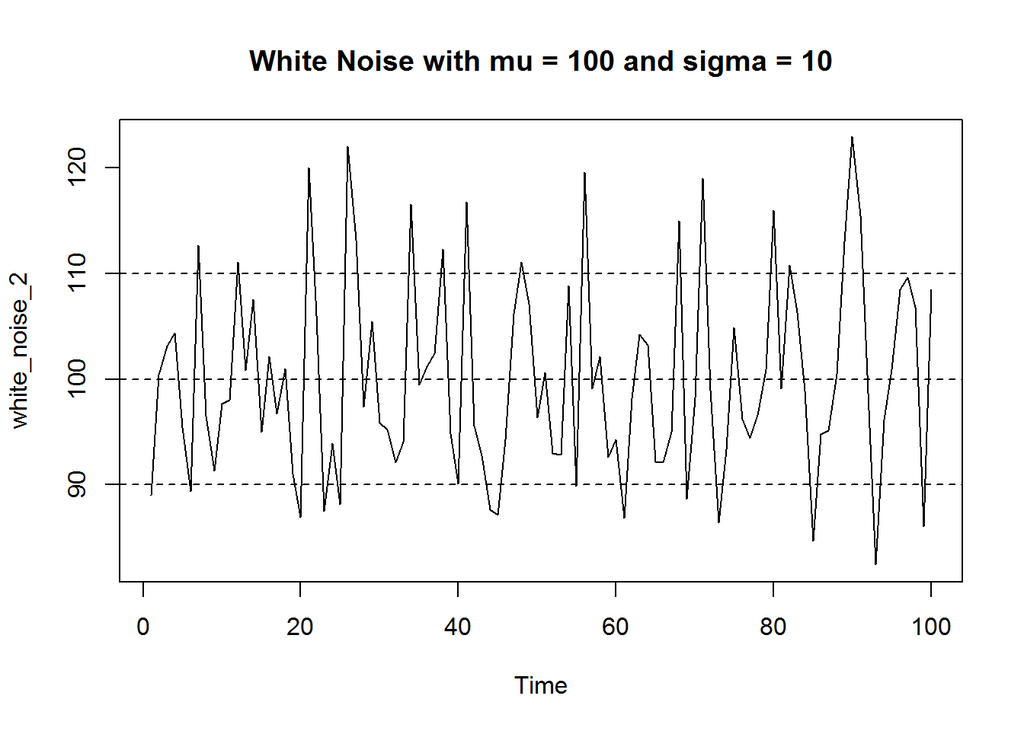

```r
white_noise_2 <- arima.sim(model = list(order=c(0,0,0)), n = 100, mean = 100, sd = 10)
plot(white_noise_2, main="White Noise with mu = 100 and sigma = 10")
abline(h=c(90,100,110), lty=2)
```

## 7.3 Estimate WN model and compare sample mean and variance

```r
arima(white_noise_2, order=c(0,0,0))
```

```
Call:
arima(x = white_noise_2, order = c(0, 0, 0))

Coefficients:
      intercept
       100.0451
s.e.     0.9315

sigma^2 estimated as 86.78:  log likelihood = -365.06,  aic = 734.12
```

The estimate mean sample mean is exactly the sample mean and the estimate variance variance approximates the sample variance.

```r
mean(white_noise_2)
```

```
[1] 100.0451
```

```r
var(white_noise_2)
```

```
[1] 87.65395
```

# 8 Random Walk (RW)

Random Walk (RW) is a simple example of an unstable or non-stationary process.

A random walk has:

- No specified mean or variance
- Strong dependence over time, with each observation closely related to its imediate neighbors
- Its changes or increments are white noise (WN) which is stable and stationary

**Randow Walk recursion:**

$$Today = Yesterday + Noise$$

More formally:

$$Y_t = Y_{t-1} + \epsilon_t$$

This error $\epsilon_t$ is *mean zero white noise* (WN)

- Simulating RW requires an initial point $Y_0$
- Given $Y_0$ and the first WN term it’s generated the first RW observation
- And then proceed with the next time index
- Often the value zero is used as initial point $Y_0$ for simplicity
- The RW model has only one parameter, the WN variance $\sigma_\epsilon^2$

**Random Walk process::**

The terms in RW can be arrange as a *fist difference series*

$$Y_t - Y_{t-1} = \epsilon_t \rightarrow diff(Y) \ is \ WN$$

## 8.1 Simulate the random walk model

The random walk (RW) model is also a basic time series model. It is the cumulative sum (or integration) of a mean zero white noise (WN) series, such that the first difference series of a RW is a WN series. Note for reference that the RW model is an ARIMA(0, 1, 0) model, in which the middle entry of 1 indicates that the model’s order of integration is 1.

The arima.sim() function can be used to simulate data from the RW by including the model = list(order = c(0, 1, 0)) argument. We also need to specify a series length n. Finally, you can specify a sd for the series (increments), where the default value is 1.

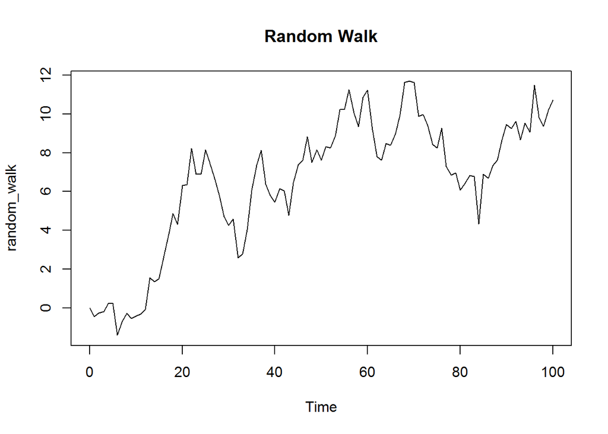

```r
random_walk <- arima.sim(model = list(order=c(0,1,0)), n = 100)
plot(random_walk, main="Random Walk")
```

## 8.2 Calculate the first difference series of the RW model

The first difference of your random_walk data is white noise data. This is because a random walk is simply recursive white noise data. By removing the long-term trend, you end up with simple white noise.

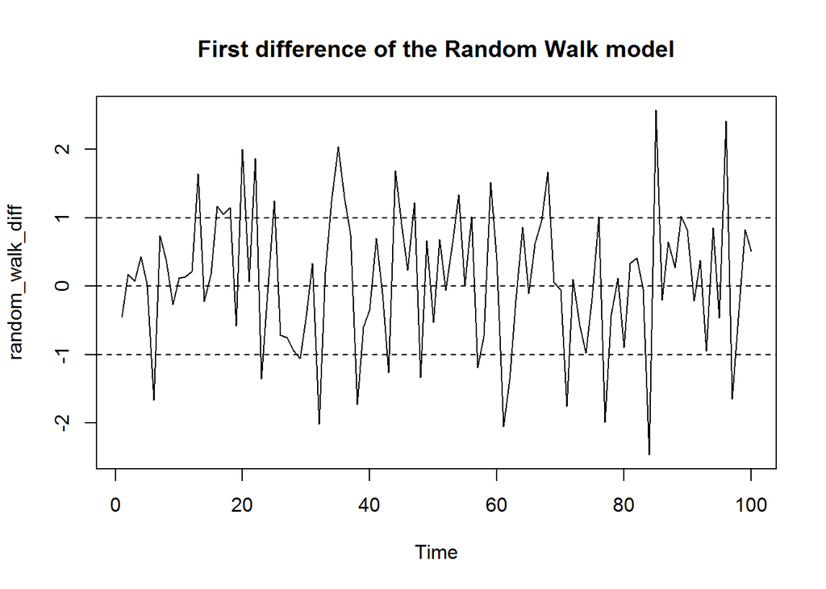

```r
random_walk_diff <- diff(random_walk)
plot(random_walk_diff, main="First difference of the Random Walk model")
abline(h=c(-1,0,1), lty=2)
```

## 8.3 Randow Walk with a Drift

The Random Walk model can be extended to include an Intercept or Drift Coefficient. This adds a constant $c$ to the recursive formula:

$$Today = Constant + Yesterday + Noise$$

More formally:

$$Y_t = c + Y_{t-1} + \epsilon_t$$

This error $\epsilon_t$ is *mean zero white noise* (WN)

- The RW model has two parameters, constant $c$ and the WN variance $\sigma_\epsilon^2$

The first difference of a RW with a Drift is simply a constant + Noise

$$Y_t - Y_{t-1} = c + \epsilon_t \rightarrow WN \ with \ mean \ c$$

### 8.3.1 Simulate the random walk model with a drift, e.g., $\mu$=1

A random walk (RW) need not wander about zero, it can have an upward or downward trajectory, i.e., a drift or time trend. This is done by including an intercept in the RW model, which corresponds to the slope of the RW time trend.

For an alternative formulation, you can take the cumulative sum of a constant mean white noise (WN) series, such that the mean corresponds to the slope of the RW time trend.

To simulate data from the RW model with a drift you again use the arima.sim() function with the model = list(order = c(0, 1, 0)) argument. This time, you should add the additional argument mean = … to specify the drift variable, or the intercept.

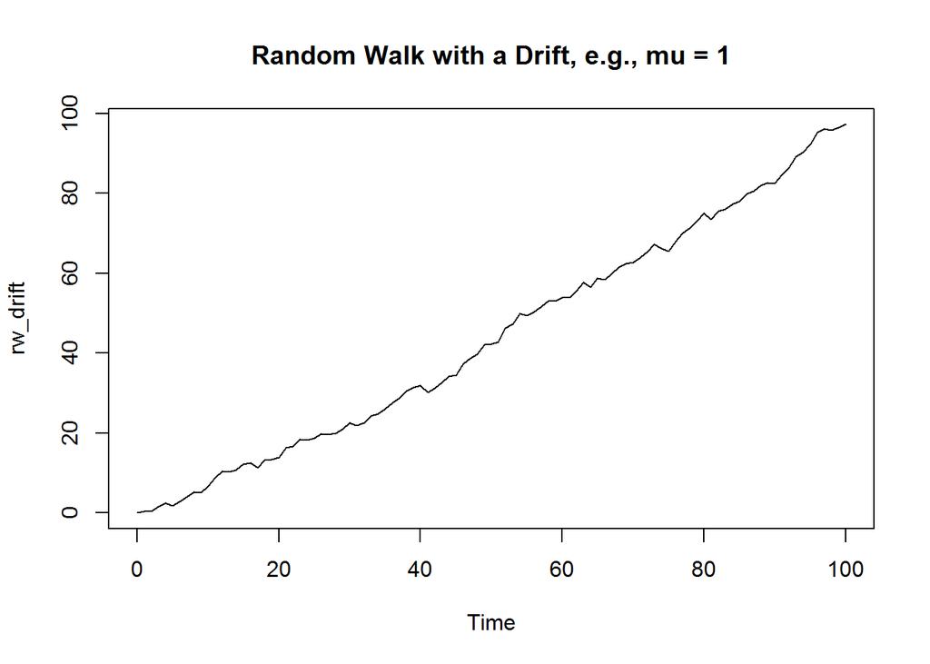

```r
rw_drift <- arima.sim(model = list(order=c(0,1,0)), n = 100, mean = 1)
plot(rw_drift, main="Random Walk with a Drift, e.g., mu = 1")
```

### 8.3.2 Calculate the first difference series of a RW model with a Drift

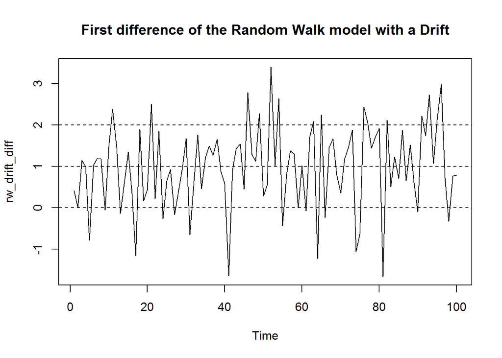

```r
rw_drift_diff <- diff(rw_drift,1)
plot(rw_drift_diff, main="First difference of the Random Walk model with a Drift")
abline(h=c(0,1,2), lty=2)
```